# Matemáticas Uno

John Jairo Estrada Álvarez

2021-01-28

## Presentación del curso

### Profesor del curso

John Jairo Estrada Álvarez

- Matemático UdeA
- Matemático UNAL
- Magister en Matemática Aplicadas Eafit (Enfásis en control y automatización)

**Profesor de tiempo completo UCES**

#### Profesor de las asignaturas

- Algebra y trigonometría
- Geometrìa Vectorial
- Fundamentos de Matemáticas
- Cálculo I, Cálculo II, Cálculo III
- Matemáticas I, Matemáticas II, Matemáticas III, Matemáticas IV
- Matemáticas discretaas I, Matemáticas discretas II, Matemáticas discretaas III
- Algebra lineal
- Ecuaciones Difeenciales
- Programación I
- Análisis Numérico con aplicaciones
- Control Automático I
- Análisis de datos
- Bioestadística I

#### Universidades donde a trabajado como docente

- Universidad EIA
- Universidad EAFIT
- Universidad UdeA
- Universidad Bolivariana
- Universidad de Envigado
- Politécnico JIC
- Institución universitaria ITM
- Universidad Antonio Nariño (sede medellín)

## **Matemáticas Uno**

#### Objetivo general

Resolver problemas matemáticos para desarrollar el pensamiento lógico y deductivo, utilizando las leyes y principios de la lógica matemática, para que le permita razonar de manera adecuada con creatividad.

#### Objetivos específicos

- Iniciar el estudio de los conjuntos numéricos y caracterizar sus propiedades básicas para resolver desigualdades y sus diversas aplicaciones
- Resolver desigualdades entre números reales para aplicar su soluciones en diferentes escenarios de la Biología, Ecología y Química Farmacéutica.
- Efectuar operaciones de aritmética básica
- Fundamentar la proporcionalidad directa e inversa
- Efectuar simplificar expresiones algebraicas.
- Categorizar el número de raíces reales de un polinomio, calcular algunas de ellas.
- Describir las funciones trigonométricas a partir de la relación existente entre el triángulo rectángulo, y el círculo unitario, para resolver problemas trigonométricos en diversas disciplinas de la ciencias aplicadas.

### **Clase a clase**

#### **Sistema numérico de la línea Real**

- Concepto de conjunto y sus propiedades básicas
- Conjuntos numéricos y su clasificación
- Concepto de distancia en la linea real
- Desigualdades y sus propiedades
- concepto de valor absoluto y sus propiedades
- Desigualdades con valor absoluto

#### **Algebra**

- Productos notables
- Factorización.
- Simplificación de expresiones racionales
- Expresiones racionales compuestas
- Potenciación y radicación
- Polinomios
- Teorema del residuo y teorema del factor
- Raíces racionales de un polinomio Teorema fundamental del álgebra
- Ley de signos de Descartes
- Factorización sobre complejos
- Aproximación de raíces irracionales (Métodos de Bisección, Regla Falsa y Secante).

#### **Sistema de coordenadas cartesianas**

- Distancia
- Ecuación de la recta
- Ecuación de la circunferencia
- Funciones (Dominio y Rango)
- Operaciones con funciones
- Problemas de aplicación

#### **Funciones exponencial y logarítmica**

- Propiedades de la función exponencial.
- Representación gráfica de la función exponencial.
- Ecuaciones exponenciales y su solución.
- Propiedades de la funcion logaritmica.
- Representición gráfica de la función logaritmica.
- Ecuaciones logaritmicas y su solución.
- Problemas de la función exponencial y logaritmica.

#### **Trigonometría**

- Definiciones básicas
- Definición de las funciones trigonometricas a partir del triángulo rectángulo.
- Aplicaciones trigonometricas usando el triángulo rectángulo.
- Relación entre el triangulo rectángulo y el círculo unitario.
- Valores trigonometricos para los ángulos básicos en el círculo unitario.
- Identidades básicas.
- Funciones trigonometricas inversas básicas.
- Ecuaciones trigonometricas.
- Teorema del seno.
- Teorema del coseno.

## Fechas de Evaluación primer semestre 2021

### GrupoA

- Primer parcial (25 $\%$) - **Fecha: Viernes $26$ de Febrero**
- Segundo Parcial (25 $\%$) - **Fecha: Viernes $26$ de Marzo**
- Tercer Parcial (25 $\%$) - **Fecha: Viernes $30$ de Abril**
- Fin de clases 28 de Mayo
- Cuarto Parcial (ó Parcial Final) (25 $\%$) - **Fecha: Viernes $28$ de Mayo**

### GrupoB

- Primer parcial (25 $\%$) - **Fecha: Jueves $25$ de Febrero**
- Segundo Parcial (25 $\%$) - **Fecha: Jueves $25$ de Marzo**
- Tercer Parcial (25 $\%$) - **Fecha: Jueves $29$ de Abril**
- Fin de clases 28 de Mayo
- Cuarto Parcial (ó Parcial Final) (25 $\%$) - **Fecha: Jueves $27$ de Mayo**

```
## ~~ Package calendR
## Visit https://r-coder.com/ for R tutorials ~~
```

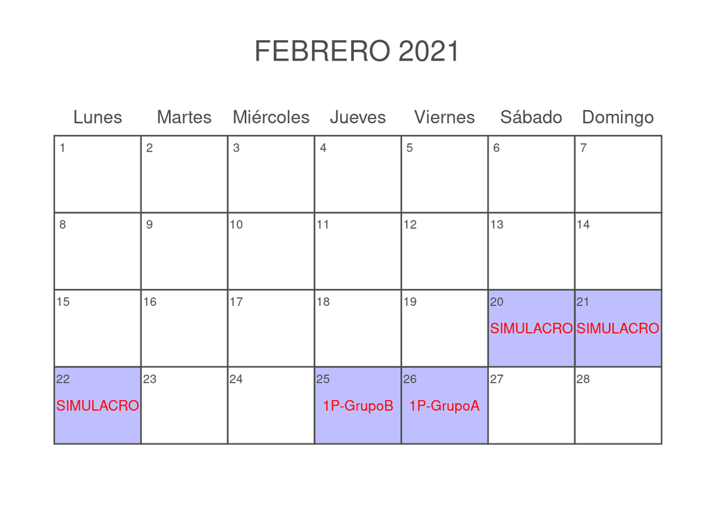

## Bibliografía

- Dennis Zill, Algebra y trigonometría con Geometría Analítica, 8 ed. Mc Graw Hill
- SWOKOWSKI, Earl. Álgebra y Trigonometría con Geometría Analítica. 9ª ed. México. Thomson. 1998. 976p.
- DIEZ, Luis. Matemáticas Operativas. 15ª ed. Medellín. Zona Dinámica. 1998, 289p.
- ALLENDOFER, Carl & Oakley, Cletus. Matemáticas Universitarias. 4ª ed. Bogotá. McGraw-Hill. 2003. 383p.
- STEWART, JAMES. precálculo. Matemáticas para el Cálculo. 5ª ed. México. Thomson. 2007. 933 p.
- SPIEGEL, Murray. Álgebra Superior. México. McGraw-Hill. 1997. 312p.

## Video

La matemáticas nos hace más libres y menos manipulables: https://www.youtube.com/watch?v=BbA5dpS4CcI&t=2516s.

[video not shown]